# Tables and figures in R

Tham, Wei Yang

November 16, 2017

Good tables and figures are an essential component of every paper. In general, I prefer figures to tables, especially for presenting regression coefficients. I find that most economists use tables too often for my liking, both in papers and presentations. In this document, we’ll focus mostly on how to make plots in R with the `ggplot2` package and how to integrate them into a document. We’ll use other data-wrangling tools from the `tidyverse` where necessary. We’ll do a little bit on tables at the end.

Other resources, some of which I’ve drawn upon for this workshop:

- Karthik Ram’s [slides](https://speakerdeck.com/karthik/introduction-to-ggplot2)
- [R for Data Science](http://r4ds.had.co.nz/data-visualisation.html)
- [Harvard Institute for Quantitative Social Science tutorials](http://tutorials.iq.harvard.edu/R/Rgraphics/Rgraphics.html#statistical_transformations)
- [Building up a ggplot2 figure from its defaults](https://hopstat.wordpress.com/2016/02/18/how-i-build-up-a-ggplot2-figure/)
- [The ggplot2 page](http://ggplot2.tidyverse.org/)
- [Karl Broman’s tips for figures and tables](http://kbroman.org/knitr_knutshell/pages/figs_tables.html)
- [stargazer cheatsheet for building tables](http://www.jakeruss.com/cheatsheets/stargazer/)

## Why ggplot2?

ggplot2 is based on the grammar of graphics, a phrase coined by Lee Wilkinson. The “grammer” means there is an underlying logic to building a plot. This makes it easier to understand the code used to build a plot, and a lot less effort to memorize arbitrary commands.

ggplot2 also comes with nice defaults. This means it takes a lot less work get your graphic to a stage where you’re satisfied. It’s also just a lot more fun to be able to make nice graphs without too much effort. If you want some tips on taking a ggplot2 figure to the next level, check out [this tutorial](https://hopstat.wordpress.com/2016/02/18/how-i-build-up-a-ggplot2-figure/)

## Basics

- `ggplot()` - main function where you specify the dataset and variables to plot
- `geoms` - geometric objects
  - E.g. `geom_point()`, `geom_bar()`, `geom_line()`
- `aes` - aesthetics
  - shape, transparency (alpha), color, fill, linetype
- scales - continuous, discrete, log
- **Side note** - Don’t use `qplot()`. Stands for “quick plot”, but tricky to add complexity

## Getting started

We’ll start with the `gapminder` dataset, which you can get by installing the `gapminder` package. Make sure you have the `tidyverse` packages too.

```r
install.packages("tidyverse")
install.packages("gapminder")
```

Take a quick peek at the dataset

```r
library(tidyverse)
library(gapminder)
gapminder
```

```
## # A tibble: 1,704 x 6
##        country continent  year lifeExp      pop gdpPercap
##         <fctr>    <fctr> <int>   <dbl>    <int>     <dbl>
##  1 Afghanistan      Asia  1952  28.801  8425333  779.4453
##  2 Afghanistan      Asia  1957  30.332  9240934  820.8530
##  3 Afghanistan      Asia  1962  31.997 10267083  853.1007
##  4 Afghanistan      Asia  1967  34.020 11537966  836.1971
##  5 Afghanistan      Asia  1972  36.088 13079460  739.9811
##  6 Afghanistan      Asia  1977  38.438 14880372  786.1134
##  7 Afghanistan      Asia  1982  39.854 12881816  978.0114
##  8 Afghanistan      Asia  1987  40.822 13867957  852.3959
##  9 Afghanistan      Asia  1992  41.674 16317921  649.3414
## 10 Afghanistan      Asia  1997  41.763 22227415  635.3414
## # ... with 1,694 more rows
```

### Creating a plot

Try creating your first plot with this code.

```r
ggplot(gapminder)
```

Ha! Sorry. Try this instead.

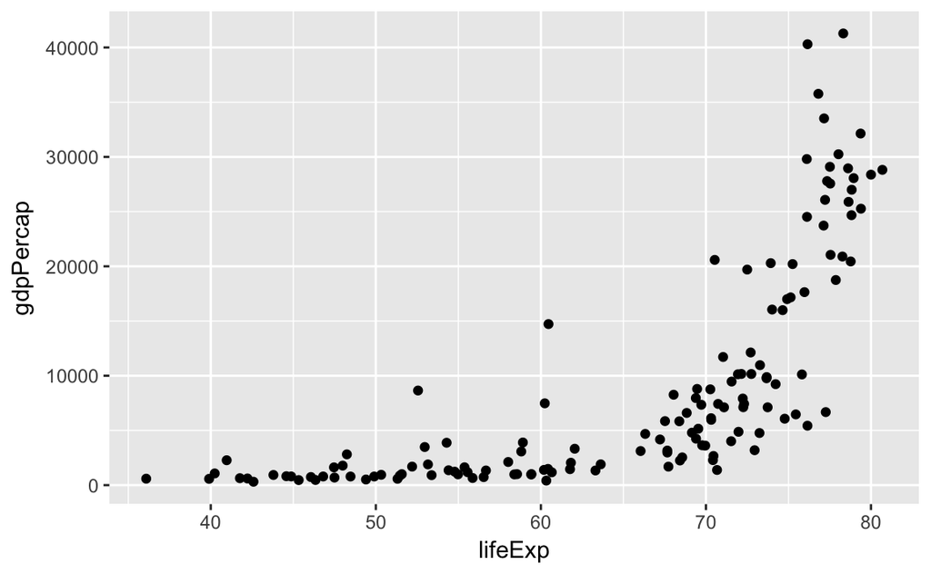

```r
ggplot(data = filter(gapminder, year == 1997),
       mapping = aes(x = lifeExp, y = gdpPercap)) +
  geom_point()
```

`ggplot()` creates a coordinate system that you can add layers to. To create a graph, you need to specify your

- `data`
- `mapping` - this defines how variables in your dataset are mapped to visual properties (in this case, the x and y axes)

### Points

- Increase the size

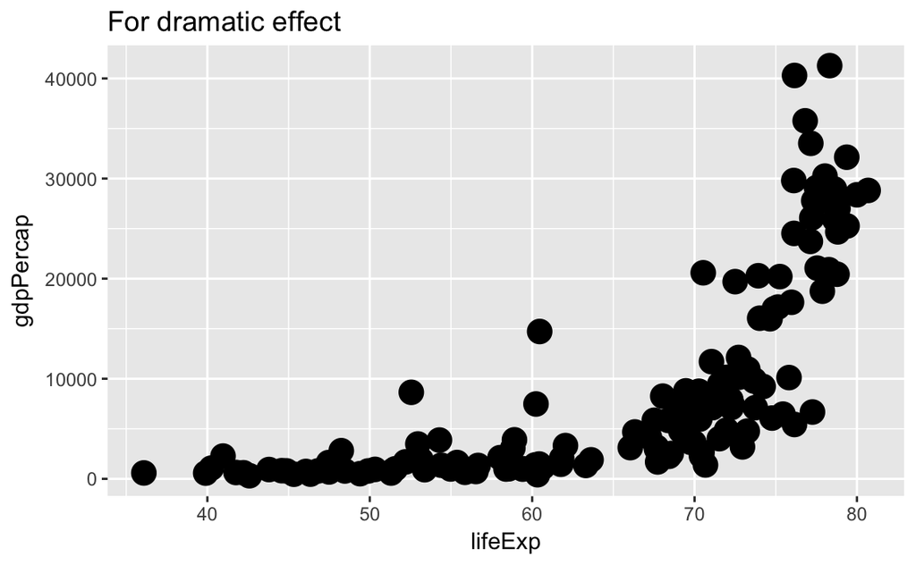

```r
ggplot(data = filter(gapminder, year == 1997),
       mapping = aes(x = lifeExp, y = gdpPercap)) +
  geom_point(size = 5) +
  ggtitle("For dramatic effect")
```

- Different colours by continent

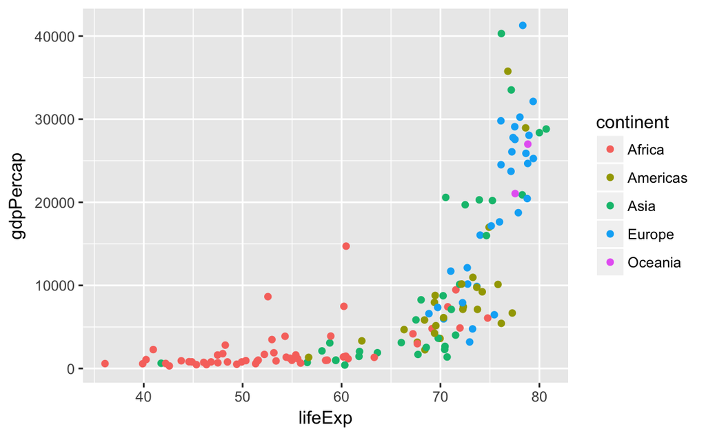

```r
ggplot(data = filter(gapminder, year == 1997),
       mapping = aes(x = lifeExp, y = gdpPercap, colour = continent)) +
  geom_point()
```

Try this:

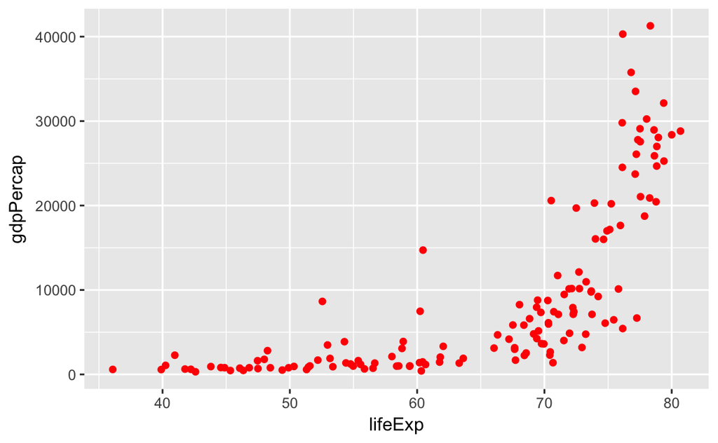

```r
ggplot(data = filter(gapminder, year == 1997),
       mapping = aes(x = lifeExp, y = gdpPercap)) +
  geom_point(color = "red")
```

and this:

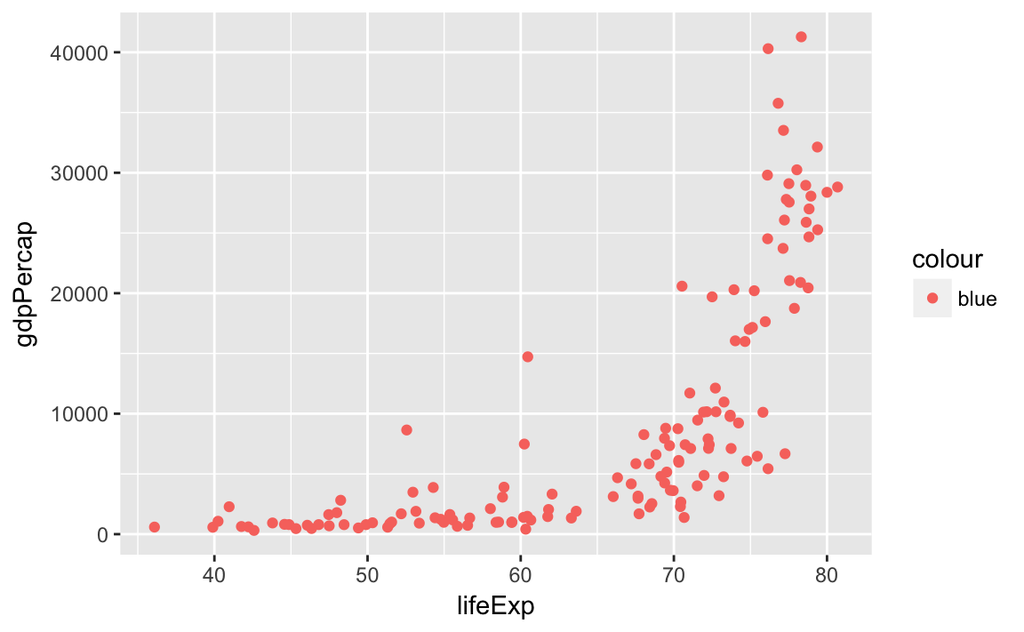

```r
ggplot(data = filter(gapminder, year == 1997),
       mapping = aes(x = lifeExp, y = gdpPercap, color = "blue")) +
  geom_point()
```

#### Point aesthetics

Different geoms understand different aesthetics. Type `?geom_point` in your console and scroll down to the `Aesthetics` section. The help document says that `geom_point` understands the shape aesthetic, so we can differentiate continents by shapes *and* colours. Shapes are helpful to accommodate black-and-white versions of your paper.

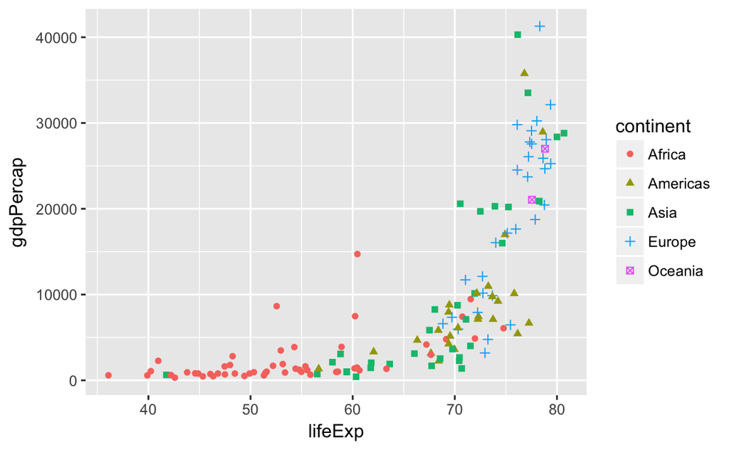

```r
ggplot(data = filter(gapminder, year == 1997),
       mapping = aes(x = lifeExp, y = gdpPercap, shape = continent, color = continent)) +
  geom_point()
```

### Lines

Let’s look at average worldwide life expectancy over time. We’ll calculate mean life expectancy each year and then 95% confidence intervals.

```r
lifexp = gapminder %>%
  group_by(year) %>%
  summarize(lifexp_mean = mean(lifeExp), lifexp_se = sd(lifeExp)/sqrt(n()))

lifexp = mutate(lifexp,
                     lifexp_upperci = lifexp_mean + 1.96*lifexp_se,
                     lifexp_lowerci = lifexp_mean - 1.96*lifexp_se)

lifexp
```

```
## # A tibble: 12 x 5
##     year lifexp_mean lifexp_se lifexp_upperci lifexp_lowerci
##    <int>       <dbl>     <dbl>          <dbl>          <dbl>
##  1  1952    49.05762 1.0259794       51.06854       47.04670
##  2  1957    51.50740 1.0264267       53.51920       49.49560
##  3  1962    53.60925 1.0151782       55.59900       51.61950
##  4  1967    55.67829 0.9834247       57.60580       53.75078
##  5  1972    57.64739 0.9551523       59.51948       55.77529
##  6  1977    59.57016 0.9421682       61.41681       57.72351
##  7  1982    61.53320 0.9038502       63.30474       59.76165
##  8  1987    63.21261 0.8858638       64.94891       61.47632
##  9  1992    64.16034 0.9421808       66.00701       62.31366
## 10  1997    65.01468 0.9700466       66.91597       63.11338
## 11  2002    65.69492 1.0304998       67.71470       63.67514
## 12  2007    67.00742 1.0131454       68.99319       65.02166
```

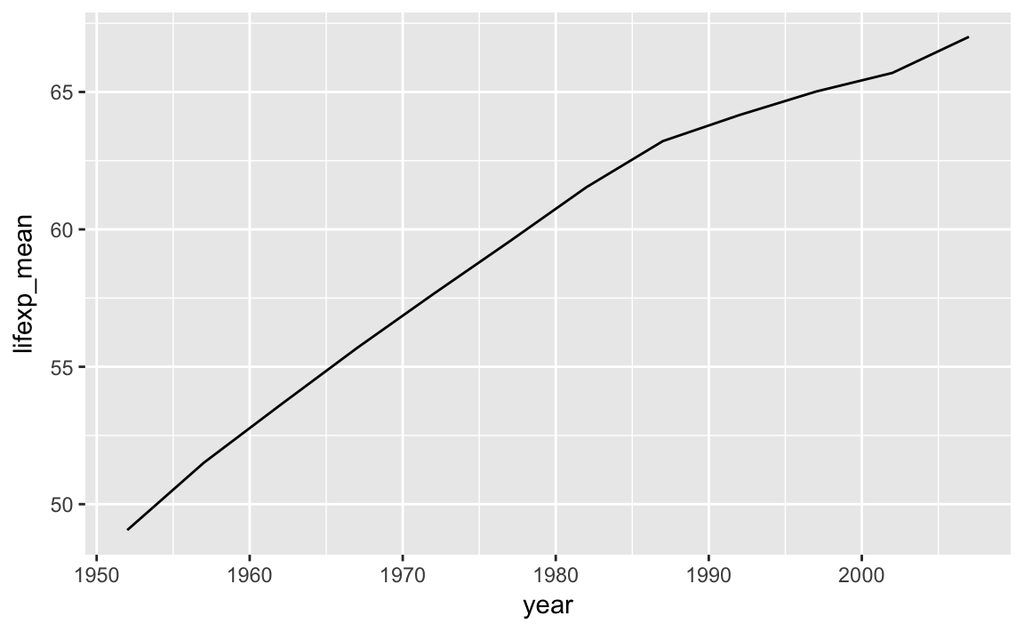

```r
ggplot(lifexp, aes(year, lifexp_mean)) +
  geom_line()
```

You’ll often want to show the confidence intervals e.g. if you have regression coefficients from an event study.

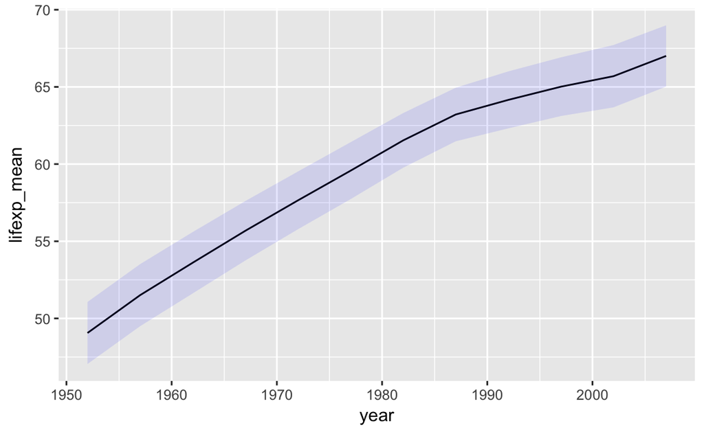

```r
ggplot(lifexp, aes(year, lifexp_mean)) +
  geom_line() +
  geom_ribbon(aes(ymin = lifexp_lowerci, ymax = lifexp_upperci), alpha = 1/10, fill = "blue")
```

You can also do errorbars.

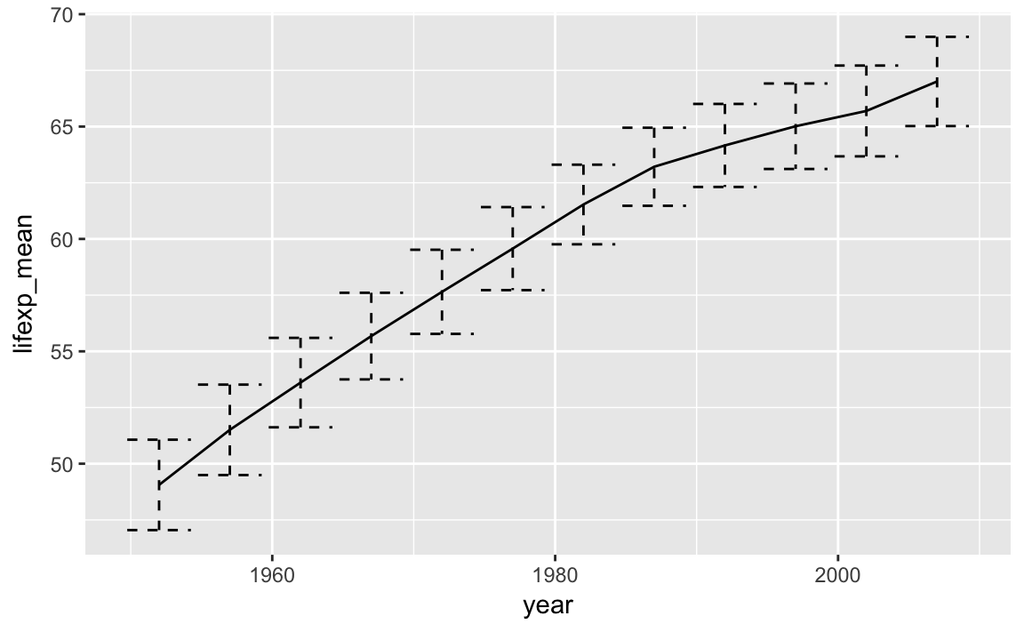

```r
ggplot(lifexp, aes(year, lifexp_mean)) +
  geom_line() +
  geom_errorbar(aes(ymax = lifexp_upperci, ymin = lifexp_lowerci), linetype = 2)
```

You can also plot the confidence intervals as lines. I am working on a geom that does this (and I’m really close!), but for now you have this workaround.

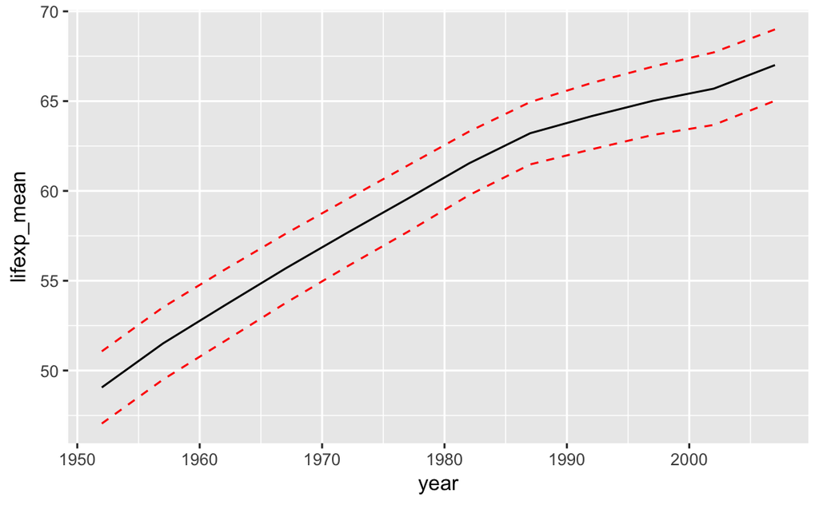

```r
ggplot(lifexp, aes(year, lifexp_mean)) +
  geom_line() +
  geom_line(aes(year, lifexp_upperci), linetype = 2, color = "red") +
  geom_line(aes(year, lifexp_lowerci), linetype = 2, color = "red")
```

### Bars

Let’s use the `nycflights13` package. Which New York airport had the most number of flights originating from it?

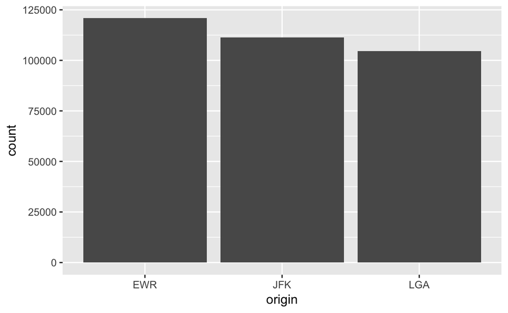

```r
# install.packages(nycflights13)
library(nycflights13)

ggplot(flights) + geom_bar(aes(origin))
```

Notice that the counting has been done for you. If you want to display values that are already in the data, use `geom_col`.

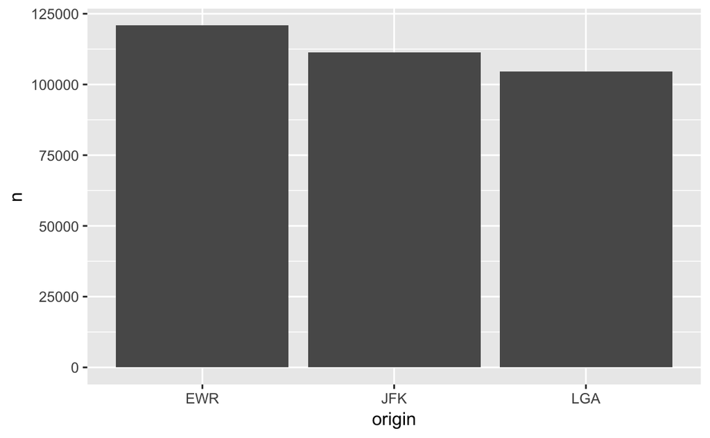

```r
origins = count(flights, origin)

origin_plot = ggplot(origins, aes(origin, n)) + geom_col()
origin_plot
```

```r
# Same thing
# ggplot(origins, aes(origin, n)) +
#   geom_bar(stat = "identity")
```

You might want to flip the bars.

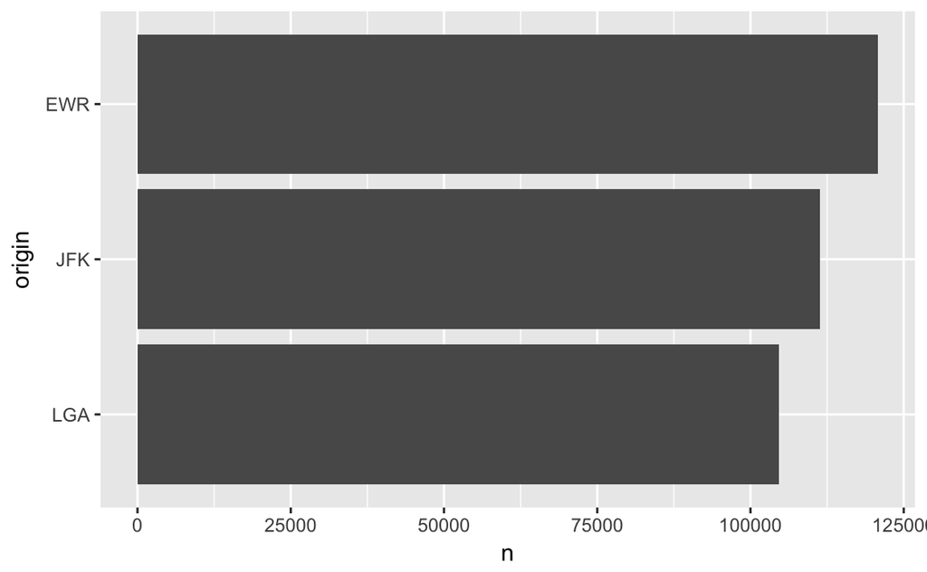

```r
origins %>%
  mutate(origin = reorder(origin, n)) %>%
  ggplot(aes(origin, n)) + geom_col() + coord_flip()
```